# Calculating Mean

April 14, 2020

## Frequentist approach

As we can consider that the target variable is distributed normally, the sample mean and sample standard deviation is good estimators for parameters.

### Mean

```r
table1 <- dt %>%
  dplyr::group_by(Component, Group) %>%
  summarise(Count = n(), Mean = mean(Gas), SD = sd(Gas),
  CI = paste0("[", round(mean(Gas) + qt(0.025, df = n()-1)*sd(Gas)/sqrt(n()),6),
  ", ", round(mean(Gas) + qt(0.975,df=n()-1)*sd(Gas)/sqrt(n()), 6), "]"),
  Dof= n()-1)

table1 %>%
  mutate_if(is.numeric, round,4) %>%
  head(10) %>%
  kable()
```

| Component | Group | Count | Mean | SD | CI | Dof |
| --- | --- | --- | --- | --- | --- | --- |
| A | n 1 10 | 5 | 0.1704 | 0.0190 | [0.146746, 0.193996] | 4 |
| A | n NA 20 | 5 | 0.0003 | 0.0001 | [0.000162, 0.000411] | 4 |
| A | o 0.5 10 | 5 | 0.1147 | 0.0112 | [0.100887, 0.128586] | 4 |
| A | o NA 20 | 5 | 0.0002 | 0.0000 | [0.000149, 0.000211] | 4 |
| A | o1 1 10 | 5 | 0.1431 | 0.0065 | [0.135011, 0.151162] | 4 |
| A | o1 NA 20 | 5 | 0.0001 | 0.0000 | [0.000124, 0.000154] | 4 |
| A | o2 0.5 10 | 5 | 0.1150 | 0.0101 | [0.102384, 0.127531] | 4 |
| A | o2 NA 20 | 5 | 0.0001 | 0.0000 | [9e-05, 0.000111] | 4 |
| A | o3 1 10 | 5 | 0.1499 | 0.0081 | [0.139951, 0.159948] | 4 |
| A | o4 0.5 10 | 5 | 0.1157 | 0.0045 | [0.110206, 0.121272] | 4 |

Estimating residual variance:

```r
table2 <- merge(dt[,c("Group", "Gas", "Component")], table1[,c("Group","Mean", "Component")], by = c("Component","Group"))
var(table2$Gas-table2$Mean)
```

```
## [1] 5.813107e-05
```

### Ratio 1 and Ratio 2

For Ratios the following estimator was used $r= \frac{\bar{x}}{\bar{y}}$.

```r
rfun <- function(mui,ratio12="n 1 10"){
  t <-  table1 %>%
  filter(Group %in% c(ratio12,mui)) %>%
  dplyr::group_by(Component) %>%
  mutate(RatioMu = Mean/Mean[Group==ratio12],
    RatioSigma = SD/SD[Group==ratio12]) %>%
  filter(RatioMu!=1) %>%
  dplyr::select(Component, Group, RatioMu,RatioSigma)
  t
}

rat1 <- rbind(rfun("n NA 20"), rfun("o NA 20"), rfun("o1 NA 20"),
  rfun("o2 NA 20"),rfun("s NA 20"))

rat2 <- rbind(rfun("n NA 20", "o2 0.5 10"), rfun("o NA 20","o2 0.5 10"),
  rfun("o1 NA 20","o2 0.5 10"), rfun("o2 NA 20","o2 0.5 10"),
  rfun("s NA 20","o2 0.5 10"))
```

Because the ratio estimate is generally skewed confidence intervals created with the variance and symmetrical tests such as the t test are incorrect, a conservative estimate of the 95% confidence intervals can be made with the Vysochanskij–Petunin inequality: $P(|X-\mu|\ge \lambda \sigma) \le \frac{4}{9 \lambda^2}$. When $\lambda = 3$ we have 0.95 so the Vysochanskij-Petunin inequality tells us that for unimodal data, 95% of the data is within 3 standard deviations of the mean.

**Ratio 1**

```r
rat1 %>%
  mutate(CI = paste0("[", round(RatioMu - 3*RatioMu/5, 3),
      ", ", round(RatioMu + 3*RatioMu/5, 3), "]"))%>%
  dplyr::select(Component, Group, RatioMu,CI) %>%
  head(10) %>%
  kable()
```

| Component | Group | RatioMu | CI |
| --- | --- | --- | --- |
| A | n NA 20 | 0.0016811 | [0.001, 0.003] |
| B | n NA 20 | 0.0015391 | [0.001, 0.002] |
| C | n NA 20 | 0.0007355 | [0, 0.001] |
| D | n NA 20 | 0.0224908 | [0.009, 0.036] |
| E | n NA 20 | 0.0052617 | [0.002, 0.008] |
| A | o NA 20 | 0.0010553 | [0, 0.002] |
| B | o NA 20 | 0.0010570 | [0, 0.002] |
| C | o NA 20 | 0.0005635 | [0, 0.001] |
| D | o NA 20 | 0.0176714 | [0.007, 0.028] |
| E | o NA 20 | 0.0041342 | [0.002, 0.007] |

**Ratio 2**

```r
rat2 %>%
  mutate(CI = paste0("[", round(RatioMu - 3*RatioMu/5, 3),
       ", ", round(RatioMu + 3*RatioMu/5, 3), "]")) %>%
  dplyr::select(Component, Group, RatioMu,CI) %>%
  head(10) %>%
  kable()
```

| Component | Group | RatioMu | CI |
| --- | --- | --- | --- |
| A | n NA 20 | 0.0024915 | [0.001, 0.004] |
| B | n NA 20 | 0.0015920 | [0.001, 0.003] |
| C | n NA 20 | 0.0006609 | [0, 0.001] |
| D | n NA 20 | 0.0200584 | [0.008, 0.032] |
| E | n NA 20 | 0.0067158 | [0.003, 0.011] |
| A | o NA 20 | 0.0015640 | [0.001, 0.003] |
| B | o NA 20 | 0.0010934 | [0, 0.002] |
| C | o NA 20 | 0.0005064 | [0, 0.001] |
| D | o NA 20 | 0.0157602 | [0.006, 0.025] |
| E | o NA 20 | 0.0052767 | [0.002, 0.008] |

## Bayesian Analysis

The mean of each group will be estimated using Bayesian inference and conjugate priors are. As we can assume that the data come from the normal distribution it is enough to model two parameters: the mean $\mu$ and the standard deviation $\sigma$. Two approaches with known and unknown variation will be demonstrated. Posterior can be explored using direct calculations (when the posterior has explicit and simple form) or simulate the posterior. We are going to use both variants for the first and simulation for the second approach.

In the **first** case we will consider Bayesian estimation of the mean of a Gaussian, whose variance is assumed to be known:

$$X_i \sim N(\mu, \sigma)$$
Keeping variance fixed, the natural conjugate prior for the mean is a Gaussian:

$$\mu \sim N(\mu_0, \sigma_0)$$
As *noninformative* priors are used, it is common to set the location hyper-parameter to zero and the scale to some large value:

$$\mu \sim N(0, 10000)$$

Since the product of two Gaussians is a Gaussian we will have Gaussian posterior probability for $\mu$ with the [following parameters](https://ocw.mit.edu/courses/mathematics/18-05-introduction-to-probability-and-statistics-spring-2014/readings/MIT18_05S14_Reading15a.pdf):

$$\mu_n = \frac{\sigma^2}{n\sigma_0^2 + \sigma^2} \mu_0 + \frac{n \sigma_0^2}{n\sigma_0^2 + \sigma^2} \bar x$$

$$\sigma_n = \frac{\sigma^2\sigma_0^2}{n \sigma_0^2+\sigma^2}$$

$\bar x$ is the sample mean, $\sigma^2$ is the sample variance.

In the **second** case we will consider Bayesian estimation of the mean of a Gaussian, whose variance is unknown. The [conjugate prior is the normal-Gamma](https://en.wikipedia.org/wiki/Conjugate_prior). Again, we are going to use *noninformative* priors. Thus we will have the following model:

Likelihood:
$$X_i \sim N(\mu, \sigma)$$
Prior
$$\mu, \; \mu \sim N(0, 10000)$$
Prior
$$\sigma^2, \; \frac{1}{\sigma^2} \sim Gamma(0.001, 0.001)$$

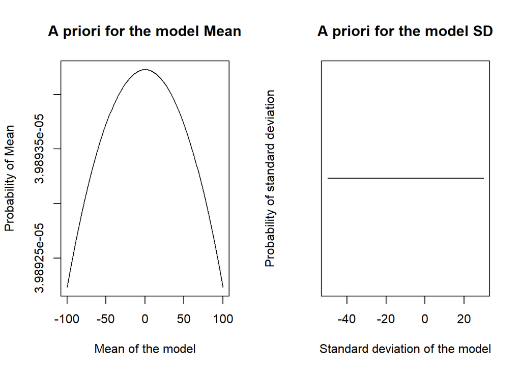

**Credible Intervals**

In Bayesian statistics typically two methods for computing credible intervals are considered: Highest Density Credible (HDI)[^1] intervals and Equal-tailed Interval (ETI). In symmetric distributions, the two methods of computing credible intervals, the ETI and the HDI return similar results. In our report, ETI was considered by calculating the quantiles of posterior distribution.

### Known variance

Now, let us consider 2 groups:

- A n 1 10
- A n NA 20

```r
y1 <- dt[dt$Component == "A" & dt$Group == "n 1 10",]$Gas
y2 <- dt[dt$Component == "A" & dt$Group == "n NA 20",]$Gas
```

Calculating the Bayesian mean of two groups using the formulas above:

```r
(mu1 = (5*mean(y1) * 10000)/(var(y1) + 5 * 10000))
```

```
## [1] 0.1703707
```

```r
(mu2 = (5*mean(y2) * 10000)/(var(y2) + 5 * 10000))
```

```
## [1] 0.0002864109
```

Calculating the Bayesian CI using the formula for $\sigma^2$ above:

```r
qnorm(p = c(0.025,0.975), mean = mu1,
  sd = sqrt((var(y1) * 10000)/(var(y1) + 5 * 10000)))
```

```
## [1] 0.1536932 0.1870483
```

```r
qnorm(p = c(0.025,0.975), mean = mu2,
  sd = sqrt((var(y2) * 10000)/(var(y2) + 5 * 10000)))
```

```
## [1] 0.0001985684 0.0003742533
```

Now we are going perform Bayesian inference using posterior simulation using R package [MCMCpack](https://cran.r-project.org/web/packages/MCMCpack/MCMCpack.pdf) and the function `MCnormalnormal`. This function generates a sample from the posterior distribution of a Normal likelihood (with known variance) with a Normal prior.

```r
set.seed(1000)
# y - data, sigma2 The known variance of y, mu0 The prior mean of mu, tau20 The prior variance of mu
posterior <- MCnormalnormal(y = y1, sigma2 = var(y1), mu0 = 0, tau20 = 10000^2)
summary(posterior)[1]$statistics
```

```
##           Mean             SD       Naive SE Time-series SE
##   0.1702645558   0.0083537912   0.0002641701   0.0002641701
```

```r
summary(posterior)[2]$quantiles
```

```
##      2.5%       25%       50%       75%     97.5%
## 0.1538894 0.1647292 0.1705623 0.1758514 0.1865071
```

```r
posterior <- MCnormalnormal(y = y2, sigma2 = var(y2), mu0 = 0, tau20 = 10000^2)
summary(posterior)[1]$statistics
```

```
##           Mean             SD       Naive SE Time-series SE
##   2.864451e-04   4.462138e-05   1.411052e-06   1.411052e-06
```

```r
summary(posterior)[2]$quantiles
```

```
##         2.5%          25%          50%          75%        97.5%
## 0.0002027582 0.0002562482 0.0002846698 0.0003163719 0.0003777770
```

It can be seen that the results of both methods are pretty similar.

**For Component A (all groups):**

```r
set.seed(1000)
X <- list()
Posterior <- list()
Mean <- NULL
DataMu <- list()

for(i in 1:11){
  X[[i]] <- dt[dt$Component == "A" & dt$Group == subgroup[i],]$Gas
  }

for(i in 1:11){
  Posterior[[i]] <- MCnormalnormal(X[[i]], sigma2 = var(X[[i]]),
    mu0 = 0, tau20 = 10000^2)
  Mean <- mean( X[[i]] )
  DataMu[[i]] <- cbind( Mu = summary(Posterior[[i]])[1]$statistics[1], SD = summary(Posterior[[i]])[1]$statistics[2],
t(as.data.frame(summary(Posterior[[i]])[2]$quantiles)), Mean )

}
```

```r
DataMuS %>%
  kable()
```

| Component | Group | Mu | 2.5% | 97.5% | Mean |
| --- | --- | --- | --- | --- | --- |
| A | n 1 10 | 0.1702646 | 0.1538894 | 0.1865071 | 0.1703707 |
| A | n NA 20 | 0.0002864 | 0.0002028 | 0.0003778 | 0.0002864 |
| A | o 0.5 10 | 0.1147276 | 0.1049718 | 0.1242913 | 0.1147364 |
| A | o NA 20 | 0.0001797 | 0.0001587 | 0.0001999 | 0.0001798 |
| A | o1 1 10 | 0.1430330 | 0.1373794 | 0.1486148 | 0.1430866 |
| A | o1 NA 20 | 0.0001393 | 0.0001287 | 0.0001504 | 0.0001394 |
| A | o2 0.5 10 | 0.1151299 | 0.1063434 | 0.1238295 | 0.1149575 |
| A | o2 NA 20 | 0.0001003 | 0.0000922 | 0.0001084 | 0.0001002 |
| A | o3 1 10 | 0.1498703 | 0.1427938 | 0.1563507 | 0.1499492 |
| A | o4 0.5 10 | 0.1157663 | 0.1119140 | 0.1194055 | 0.1157392 |
| A | s NA 20 | 0.0005997 | 0.0005279 | 0.0006780 | 0.0005994 |

For all component see the Sheet `NormalNormal`.

### Ratio 1 and 2

95% confidence intervals is created using Vysochanskij–Petunin inequality:

**Ratio 1**

```r
rfun <- function(mui, ratio12="n 1 10"){
  t <-  DataMuS %>%
  filter(Group %in% c(ratio12,mui)) %>%
  dplyr::group_by(Component) %>%
  mutate(RatioMu = Mu/Mu[Group==ratio12],
    RatioSigma = SD/SD[Group==ratio12]) %>%
  filter(RatioMu!=1) %>%
  dplyr::select(Component, Group, RatioMu,RatioSigma)
  t
}

rat1 <- rbind(rfun("n NA 20"), rfun("o NA 20"), rfun("o1 NA 20"),
  rfun("o2 NA 20"),rfun("s NA 20"))

rat2 <- rbind(rfun("n NA 20", "o2 0.5 10"), rfun("o NA 20","o2 0.5 10"),
  rfun("o1 NA 20","o2 0.5 10"), rfun("o2 NA 20","o2 0.5 10"),
  rfun("s NA 20","o2 0.5 10"))

rat1<-rat1 %>%
  mutate(CILB = RatioMu - 3*RatioMu/5,
    CIUB = RatioMu + 3*RatioMu/5)%>%
  dplyr::select(Component, Group, RatioMu,CILB, CIUB)

rat1%>%
  head(10) %>%
  kable()
```

| Component | Group | RatioMu | CILB | CIUB |
| --- | --- | --- | --- | --- |
| A | n NA 20 | 0.0016824 | 0.0006729 | 0.0026918 |
| B | n NA 20 | 0.0015434 | 0.0006174 | 0.0024694 |
| C | n NA 20 | 0.0007366 | 0.0002946 | 0.0011786 |
| D | n NA 20 | 0.0225336 | 0.0090134 | 0.0360537 |
| E | n NA 20 | 0.0052740 | 0.0021096 | 0.0084384 |
| A | o NA 20 | 0.0010551 | 0.0004220 | 0.0016882 |
| B | o NA 20 | 0.0010560 | 0.0004224 | 0.0016896 |
| C | o NA 20 | 0.0005632 | 0.0002253 | 0.0009011 |
| D | o NA 20 | 0.0177050 | 0.0070820 | 0.0283279 |
| E | o NA 20 | 0.0041439 | 0.0016575 | 0.0066302 |

**Ratio 2**

```r
rat2<-rat2 %>%
  mutate(CILB = RatioMu - 3*RatioMu/5,
    CIUB = RatioMu + 3*RatioMu/5)%>%
  dplyr::select(Component, Group, RatioMu,CILB, CIUB)
rat2%>%
  head(10) %>%
  kable()
```

| Component | Group | RatioMu | CILB | CIUB |
| --- | --- | --- | --- | --- |
| A | n NA 20 | 0.0024880 | 0.0009952 | 0.0039808 |
| B | n NA 20 | 0.0015985 | 0.0006394 | 0.0025576 |
| C | n NA 20 | 0.0006632 | 0.0002653 | 0.0010611 |
| D | n NA 20 | 0.0200438 | 0.0080175 | 0.0320702 |
| E | n NA 20 | 0.0067106 | 0.0026843 | 0.0107370 |
| A | o NA 20 | 0.0015604 | 0.0006242 | 0.0024967 |
| B | o NA 20 | 0.0010937 | 0.0004375 | 0.0017500 |
| C | o NA 20 | 0.0005071 | 0.0002028 | 0.0008113 |
| D | o NA 20 | 0.0157487 | 0.0062995 | 0.0251980 |
| E | o NA 20 | 0.0052726 | 0.0021091 | 0.0084362 |

For all component see the sheets `Ratio1NN` and `Ratio2NN`.

### Unknown variance

Now, we are going to use Gamma distribution for $\sigma^{-2}$.

**For Single Case**

```r
set.seed(1000)
x <- dt[dt$Component == "A" & dt$Group == "n 1 10",]$Gas
# b0 - the prior mean of mu, B0 - the prior precision of mu, # c0 - the shape parameter for the inverse Gamma prior on sigma^2, # d0 - the scale parameter for the inverse Gamma prior on sigma^2
posterior <- MCMCregress(x ~ 1, b0 = 0, B0 = 0, c0 = 0.001, d0 = 0.001)
summary(posterior)
```

```
##
## Iterations = 1001:11000
## Thinning interval = 1
## Number of chains = 1
## Sample size per chain = 10000
##
## 1. Empirical mean and standard deviation for each variable,
##    plus standard error of the mean:
##
##                 Mean       SD  Naive SE Time-series SE
## (Intercept) 0.170495 0.015985 1.599e-04      1.599e-04
## sigma2      0.001241 0.002033 2.033e-05      2.868e-05
##
## 2. Quantiles for each variable:
##
##                  2.5%      25%       50%      75%    97.5%
## (Intercept) 0.1389688 0.162293 0.1705265 0.178760 0.201945
## sigma2      0.0002203 0.000454 0.0007406 0.001297 0.005177
```

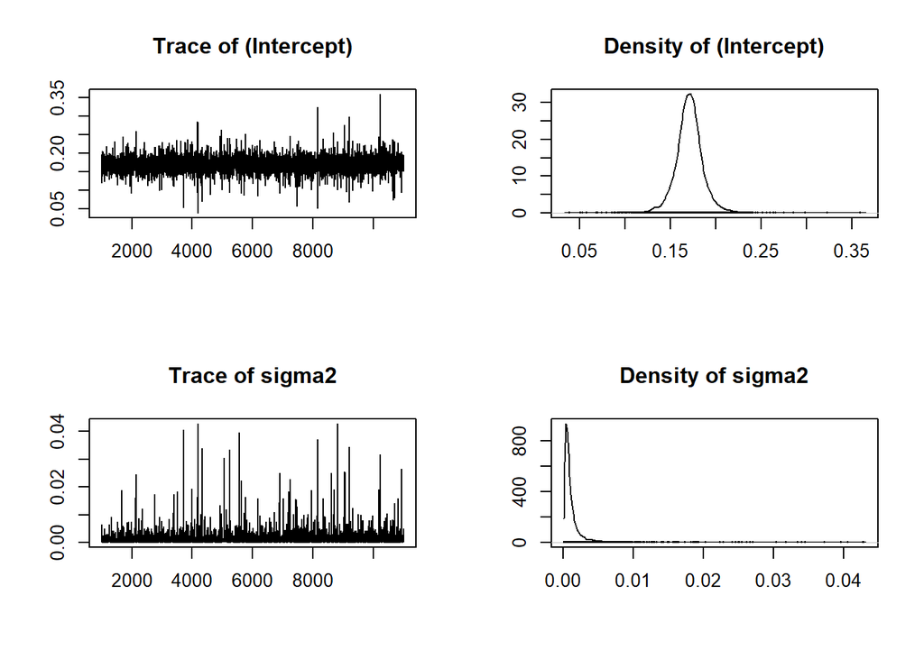

```r
plot(posterior, xlab="")
```

**For Component A (all groups)**

```r
set.seed(1000)
subgroup <- c("n 1 10", "n NA 20", "o 0.5 10","o NA 20", "o1 1 10",
  "o1 NA 20", "o2 0.5 10","o2 NA 20","o3 1 10", "o4 0.5 10", "s NA 20")
X <- list()
Posterior <- list()
Mean <- NULL
DataMu <- list()

for(i in 1:11){
  X[[i]] <- dt[dt$Component == "A" & dt$Group == subgroup[i],]$Gas
  }

for(i in 1:11){
  Posterior[[i]] <- MCMCregress(X[[i]]~1, b0 = 0, B0 =0, c0= 0.001, d0 = 0.001)
  Mean <- mean(X[[i]])
  DataMu[[i]] <- cbind( Mu = summary(Posterior[[i]])[1]$statistics[1],
as.data.frame(summary(Posterior[[i]])[2]$quantiles)[1,], Mean )

  }
```

```r
DataMuS %>%
  kable()
```

| Component | Group | Mu | 2.5% | 25% | Mean |
| --- | --- | --- | --- | --- | --- |
| A | n 1 10 | 0.1704945 | 0.1389688 | 0.1622933 | 0.1703707 |
| A | n NA 20 | 0.0003655 | -0.0197838 | -0.0048762 | 0.0002864 |
| A | o 0.5 10 | 0.1148332 | 0.0901752 | 0.1084186 | 0.1147364 |
| A | o NA 20 | 0.0002589 | -0.0198900 | -0.0049827 | 0.0001798 |
| A | o1 1 10 | 0.1431721 | 0.1213854 | 0.1375045 | 0.1430866 |
| A | o1 NA 20 | 0.0002185 | -0.0199304 | -0.0050231 | 0.0001394 |
| A | o2 0.5 10 | 0.1150514 | 0.0911243 | 0.1088270 | 0.1149575 |
| A | o2 NA 20 | 0.0001793 | -0.0199696 | -0.0050623 | 0.0001002 |
| A | o3 1 10 | 0.1500380 | 0.1274266 | 0.1441558 | 0.1499492 |
| A | o4 0.5 10 | 0.1158214 | 0.0948876 | 0.1103756 | 0.1157392 |
| A | s NA 20 | 0.0006785 | -0.0194707 | -0.0045632 | 0.0005994 |

For all component see the sheet `NormalGamma`.

### Ratio 1 and 2

The same steps as for Normal Normal case.

For all component see the sheets `Ratio1NN` and `Ratio2NN`.

[^1]: The shortest CI with a fixed probability.